# Assignment #2

Ethan Jantz

9/22/2020

This document is made using [R Markdown](https://rmarkdown.rstudio.com/), a great tool for sharing research in a way that is readable and easily reproducible.

Choose three variables that you believe measure the same underlying construct or idea.

Recode each item onto the same metric (e.g., 0-1 scaling).

Provide frequencies for each variable before and after it is recoded (old and new variables).

Calculate the alpha reliability coefficient for the scale.

Report the coefficient and what it means.

Finally, average the three new variables into an index and run a frequency of the index variable.

Provide all syntax used, and frequencies for each original variable and rescaled variable and the overall index.

```r
knitr::opts_chunk$set(echo = TRUE, message = FALSE, warning = FALSE) # R Markdown options
library(psych); library(ltm) # psych for describe(), ltm for cronbach.alpha()
library(tidyverse)
library(rmarkdown) # For accessing the functions used to display tables
library(haven) # For reading ANES2016.dta file
library(here) # For easier file referencing. See documentation at https://here.r-lib.org/

anes <- haven::read_dta("ANES2016.dta") # Reading in the data
```

### Conceptual Variables

The construct here that I want to explore is class sentiment under economic pressure, or how the disenfranchised feel about those better off. The variables that I will use to explore it are listed below, with a brief explanation as to where they fit into this construct.

[output not shown]

```r
selected <-
  anes %>%
  dplyr::select(
    "Income" = V168023,
    "Housing.Security" = V162166,
    "Sentiment.RichPeople" = V162105
  )
```

So let’s start by taking these variables and recoding them. Along the way we’ll clean the data and make sure that we clear out any incomplete responses, since we want to know the full profile of our respondents for analysis.

### Recoding the Variables

We’ll start by removing observations where the profile is incomplete for the respondent, meaning that the respondent didn’t provide answers for each questions.

```r
selected <-
  selected %>%
  dplyr::filter(
    Income >= 1,
    Housing.Security >= 0,
    Sentiment.RichPeople >= 0 & Sentiment.RichPeople <= 100
  )
```

And just to check, the min for each variable should now be 0 or more

|  | mean | min |
| --- | --- | --- |
| Income | 3.694767 | 1 |
| Housing.Security | 1.725291 | 1 |
| Sentiment.RichPeople | 56.581395 | 0 |

### Variable Values

##### **V168023**: Estimated Family Income

This is the estimated family income of the respondent.

1. Under $15,000
2. $15,000 to $29,999
3. $30,000 to $49,999
4. $50,000 to $74,999
5. $75,000 to $99,999
6. $100,000 to $249,999
7. $250,000 or more

and the frequency table

```r
table(selected$Income)
```

```
##
##   1   2   3   4   5   6   7
##  51 118 150 165  92  99  13
```

This is simple, each category refers to an income bracket that increases in quantity with the variable. I will divide it by 7, creating a scale of the following possible values: 0.14, 0.29, 0.43, 0.57, 0.71, 0.86, 1

##### **V162166**: Housing Security

Respondents answered the question: During the next 12 months, how likely is it that you will be able to make all of your rent/mortgage payments on time?

1. Extremely likely
2. Very likely
3. Moderately likely
4. Slightly likely
5. Not likely at all

and the frequency table

```r
table(selected$Housing.Security)
```

```
##
##   1   2   3   4   5
## 372 195  73  34  14
```

This variable needs a change. I want “Extremely likely” to be the highest value and “Not likely at all” to be the lowest value. I’ll solve this by dividing it by 5 and multiplying it by -1, then adding 1. This will result in a scale of the following possible values: 0.8, 0.6, 0.4, 0.2, 0

##### **V162105**: Sentiment: Rich People

This variable scales from 0 - 100, with 0 being the lowest possible rating of rich people and 100 being the highest. I will divide it by 100 to put it on a scale from 0 - 1. Here is a a table and histogram of the distribution:

```r
table(selected$Sentiment.RichPeople)
```

```
##
##   0   2  10  15  20  25  30  40  45  50  51  55  60  65  70  80  85  90 100
##  12   1   1  11   2   1  26  64   1 289   1   1  76   2  96   4  65   1  34
```

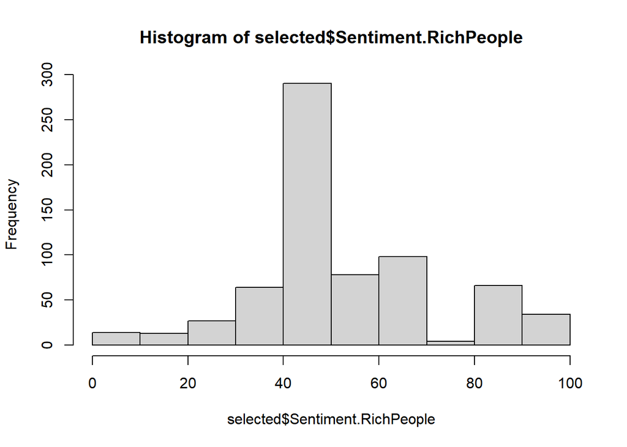

```r
hist(selected$Sentiment.RichPeople)
```

### Transforming Variables

Now I’ll transform the variables as described above.

```r
recoded <-
  selected %>%
  mutate (
    Income = round(as.numeric(Income) / 7, 2),
    Housing.Security = as.numeric(Housing.Security) / 5 * -1 + 1,
    Sentiment.RichPeople = as.numeric(Sentiment.RichPeople) / 100
  )
```

And let’s make sure we did that right:

```r
table(recoded$Income)
```

```
##
## 0.14 0.29 0.43 0.57 0.71 0.86    1
##   51  118  150  165   92   99   13
```

```r
table(recoded$Housing.Security)
```

```
##
##   0 0.2 0.4 0.6 0.8
##  14  34  73 195 372
```

```r
table(recoded$Sentiment.RichPeople)
```

```
##
##    0 0.02  0.1 0.15  0.2 0.25  0.3  0.4 0.45  0.5 0.51 0.55  0.6 0.65  0.7  0.8
##   12    1    1   11    2    1   26   64    1  289    1    1   76    2   96    4
## 0.85  0.9    1
##   65    1   34
```

### Alpha Reliability Coefficient

I’ll check the Alpha Reliability Coefficient to measure the reliability of this construct:

```r
cronbach.alpha(recoded)
```

```
##
## Cronbach's alpha for the 'recoded' data-set
##
## Items: 3
## Sample units: 688
## alpha: 0.314
```

I’m curious what would happen if I removed a variable:

```r
cronbach.alpha(recoded %>% dplyr::select(-Housing.Security))
```

```
##
## Cronbach's alpha for the 'recoded %>% dplyr::select(-Housing.Security)' data-set
##
## Items: 2
## Sample units: 688
## alpha: 0.147
```

According to [this](https://data.library.virginia.edu/using-and-interpreting-cronbachs-alpha/) page from the University of Virginia:

> the higher the α coefficient, the more the items have shared covariance and probably measure the same underlying concept.

With such a low Alpha Reliability Coefficient these variables don’t have a shared covariance, meaning they don’t seem to measure the same “concept.” However, there is reason to critically examine the usage of Cronbach’s Alpha, its common metrics and usages, and what that alpha really means. In an [article](https://journals-sagepub-com.proxy.cc.uic.edu/doi/full/10.1177/1094428114555994) from the journal of Organizational Research Methods, researchers Cho and Kim discuss the “common misconceptions” about Cronbach’s Alpha Coefficient. Among their recommendations, they emphasize that "assumptions of unidimensionality and tau-equivalency be examined before applying this alpha. I won’t be doing that in this homework, but I did feel it was worth noting. The values I’m exploring may not be unidimensional, which would limit the usefulness of Cronbach’s Alpha in interpretation.

### Creating an Index

Finally, let’s create an index of these variables and look at the descriptive statistics.

And what does this index mean? Well, a value close to 0 would mean that the respondent was in a low income bracket, felt that their ability to make consistent housing payments over the next 12 months was less likely, and had a negative sentiment towards “Rich People.” A value close to 1 would mean that the respondent was in a high income bracket, felt confident in their ability to pay their housing payments, and also had a positive sentiment towards “Rich People.” Considering the [complex](https://www.pewsocialtrends.org/2012/01/11/rising-share-of-americans-see-conflict-between-rich-and-poor/) [relationship](https://thefinancialbrand.com/81842/americans-relationship-money-wealth-rich-financial/) Americans have with wealth - and the wealthy - I think that this index may not be the best measure of the construct I was trying to build.

```r
recoded <-
  recoded %>%
  mutate(
    index = rowSums(recoded) / 3
  )

describe(recoded$index)
```

```
##    vars   n mean   sd median trimmed  mad  min  max range  skew kurtosis   se
## X1    1 688 0.58 0.13   0.59    0.59 0.13 0.11 0.93  0.82 -0.32    -0.16 0.01
```

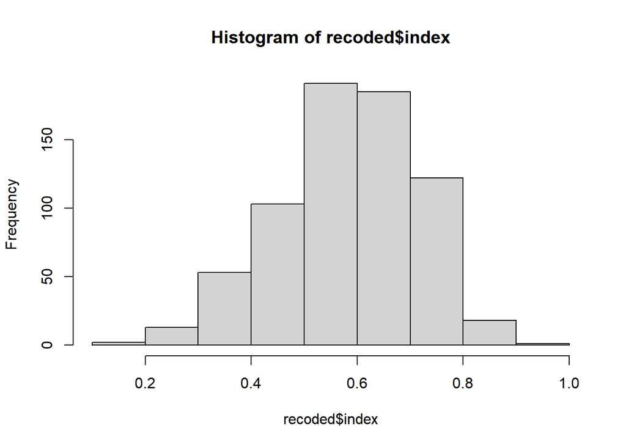

```r
hist(recoded$index)
```